# Bayesian Model with RStan

Dhafer Malouche

# Installation

## Installing `rstan` package

```r
> install.packages("rstan", repos = "https://cloud.r-project.org/", dependencies=TRUE)
```

## Checking your installation

1. *Restart R* after the installation and, before loading `RStan`, verify that no objects created by an older version of `RStan` are (perhaps auto-)loaded into `R`.
2. Verify by executing the code below in `R` and checking that it returns the value 10:

```r
> fx <- inline::cxxfunction( signature(x = "integer", y = "numeric" ) , '
+   return ScalarReal( INTEGER(x)[0] * REAL(y)[0] ) ;
+ ' )
>
> fx( 2L, 5 ) # should be 10
```

## Loading the package

Now you can load `rstan` package

```r
> rstan_options(auto_write = TRUE)
> options(mc.cores = parallel::detectCores())
```

This last option will allow you to automatically save a bare version of a compiled Stan program to the hard disk so that it does not need to be recompiled and to execute multiple Markov chains in parallel.

# Running Bayesian models: Binomial models

Assume that we have observed a random binary vector generated from a Bernoulli distribution with an unknown probability $\theta$. We will write `R` code working with `RStan` to estimate $\theta$ with a bayesian method. + Here’s a basic `stan` code. It has be saver in a `stan` file.

```r
> sink("bernoulli.stan")
> cat("
+ data { // data provided by the user
+ int<lower=1> N;
+ int<lower=0, upper=1> x[N];
+ }
+ parameters { // parameters to be inferred
+ real<lower=0, upper=1> theta;
+ }
+ model { // probability model
+ for (i in 1:N) {
+ x[i] ~ bernoulli(theta);
+ }
+ }
+ ",fill=T)
> sink()
```

Let us notice that no prior distribution is defined in the code above. We consider then by default a flat prior on the parameter $\theta$.

We will then run in the code below 4 markov chains in parallel using `rstan` command.

```r
> x_dat <- list(N = 10,
+                     x = c(1,1,1,0,0,1,0,0,1,0))
>
> fit0 <- stan(file = 'bernoulli.stan', data = x_dat,
+             iter = 1000, chains = 4)
```

Let us now print the result:

```r
> print(fit0)
```

```
## Inference for Stan model: bernoulli.
## 4 chains, each with iter=1000; warmup=500; thin=1;
## post-warmup draws per chain=500, total post-warmup draws=2000.
##
##        mean se_mean   sd   2.5%   25%   50%   75% 97.5% n_eff Rhat
## theta  0.50    0.00 0.14   0.24  0.39  0.50  0.60  0.77   819    1
## lp__  -8.85    0.03 0.74 -11.04 -9.05 -8.57 -8.37 -8.32   744    1
##
## Samples were drawn using NUTS(diag_e) at Tue Oct  9 21:06:24 2018.
## For each parameter, n_eff is a crude measure of effective sample size,
## and Rhat is the potential scale reduction factor on split chains (at
## convergence, Rhat=1).
```

`Rhat` and `n.eff` are respectively the paramters $\widehat{R}$ and $n.eff$ already defined in the Kernel: https://www.kaggle.com/dhafer/two-sample-mean-with-bayesian-approach

Let us introduce a Beta prior in the model. This prior has to be added in the `model` part of the `stan` code.

```r
> sink("bernoulli_beta.stan")
> cat("
+     data { // data provided by the user
+     int<lower=1> N;
+     int<lower=0, upper=1> x[N];
+     }
+     parameters { // parameters to be inferred
+     real<lower=0, upper=1> theta;
+     }
+     model { // probability model
+     for (i in 1:N) {
+     x[i] ~ bernoulli(theta);
+     }
+     theta ~ beta(2,3);
+     }
+     ",fill=T)
> sink()
```

Let us then run the Markov chain.

```r
> fit1 <- stan(file = 'bernoulli_beta.stan', data = x_dat,
+             iter = 1000, chains = 4)
```

Here’s then the result

```r
> print(fit1)
```

```
## Inference for Stan model: bernoulli_beta.
## 4 chains, each with iter=1000; warmup=500; thin=1;
## post-warmup draws per chain=500, total post-warmup draws=2000.
##
##         mean se_mean   sd   2.5%    25%    50%    75%  97.5% n_eff Rhat
## theta   0.47    0.00 0.12   0.24   0.38   0.46   0.55   0.71   804 1.01
## lp__  -10.87    0.02 0.69 -12.90 -11.03 -10.59 -10.42 -10.36  1074 1.00
##
## Samples were drawn using NUTS(diag_e) at Tue Oct  9 21:24:20 2018.
## For each parameter, n_eff is a crude measure of effective sample size,
## and Rhat is the potential scale reduction factor on split chains (at
## convergence, Rhat=1).
```

# Regression Model with `Stan`

We will see now how to perform a regression analysis in `Stan` using a simulated data.

We will first write the `Stan` code:

```r
> sink("regression_model.stan")
> cat("
+ data {
+   int N; //the number of observations
+   int N2; //the size of the new_X matrix
+   int K; //the number of columns in the model matrix
+   real y[N]; //the response
+   matrix[N,K] X; //the model matrix
+   matrix[N2,K] new_X; //the matrix for the predicted values
+ }
+ parameters {
+   vector[K] beta; //the regression parameters
+   real sigma; //the standard deviation
+ }
+ transformed parameters {
+   vector[N] linpred;
+   linpred <- X*beta;
+ }
+ model {
+   beta[1] ~ cauchy(0,10); //prior for the intercept following Gelman 2008
+
+   for(i in 2:K)
+    beta[i] ~ cauchy(0,2.5);//prior for the slopes following Gelman 2008
+
+   y ~ normal(linpred,sigma);
+ }
+ generated quantities {
+   vector[N2] y_pred;
+   y_pred <- new_X*beta; //the y values predicted by the model
+ }
+ ",fill=T)
> sink()
```

Let us run then a code to have a simulated data.

```r
> set.seed(45679)
> #the explanatory variables
> dat<-data.frame(x1=runif(100,-2,2),x2=runif(100,-2,2))
>
> #the model
> X<-model.matrix(~x1*x2,dat)
>
> #the regression slopes
> betas<-runif(4,-1,1)
>
> #the standard deviation for the simulated data
> sigma<-1
>
> #the simulated data
> y_norm<-rnorm(100,X%*%betas,sigma)
>
> #a matrix to get the predicted y values
> new_X<-model.matrix(~x1*x2,expand.grid(x1=seq(min(dat$x1),max(dat$x1),length=20),x2=c(min(dat$x2),mean(dat$x2),max(dat$x2))))
```

Here’s the simulated data

```r
> head(X)
```

```
##   (Intercept)         x1         x2      x1:x2
## 1           1 -1.2348436 -1.5828201  1.9545353
## 2           1 -1.0591624 -1.4874576  1.5754591
## 3           1 -0.7649926 -0.7619479  0.5828845
## 4           1  0.7396569  0.9321936  0.6895035
## 5           1  1.6214369 -1.2332682 -1.9996667
## 6           1  0.3058477  1.4795903  0.4525294
```

```r
> y_norm[1:4]
```

```
## [1] -0.4805345 -0.1069732  1.4658954 -0.2114544
```

```r
> head(new_X)
```

```
##   (Intercept)         x1        x2    x1:x2
## 1           1 -1.9843290 -1.989904 3.948625
## 2           1 -1.7771681 -1.989904 3.536394
## 3           1 -1.5700072 -1.989904 3.124164
## 4           1 -1.3628463 -1.989904 2.711934
## 5           1 -1.1556854 -1.989904 2.299703
## 6           1 -0.9485245 -1.989904 1.887473
```

We will run now the Markov Chain with `rstan`

```r
> m_norm<-stan(file="regression_model.stan",data = list(N=100,N2=60,K=4,y=y_norm,X=X,new_X=new_X),pars = c("beta","sigma","y_pred"))
```

```r
print(m_norm)
```

```
## Inference for Stan model: regression_model.
## 4 chains, each with iter=2000; warmup=1000; thin=1;
## post-warmup draws per chain=1000, total post-warmup draws=4000.
##
##              mean se_mean   sd   2.5%    25%    50%    75%  97.5% n_eff
## beta[1]     -0.15    0.00 0.09  -0.33  -0.21  -0.15  -0.09   0.03  4000
## beta[2]     -0.10    0.00 0.09  -0.27  -0.16  -0.10  -0.04   0.08  4000
## beta[3]     -0.50    0.00 0.09  -0.67  -0.56  -0.50  -0.44  -0.32  4000
## beta[4]     -0.84    0.00 0.08  -0.99  -0.89  -0.84  -0.78  -0.68  4000
## sigma        0.91    0.00 0.07   0.78   0.86   0.90   0.95   1.06  4000
## y_pred[1]   -2.26    0.00 0.31  -2.88  -2.47  -2.26  -2.05  -1.66  4000
## y_pred[2]   -1.94    0.00 0.29  -2.50  -2.13  -1.93  -1.74  -1.38  4000
## y_pred[3]   -1.61    0.00 0.26  -2.12  -1.79  -1.61  -1.43  -1.10  4000
## y_pred[4]   -1.29    0.00 0.24  -1.75  -1.45  -1.29  -1.12  -0.83  4000
## y_pred[5]   -0.96    0.00 0.22  -1.39  -1.12  -0.97  -0.81  -0.55  4000
## y_pred[6]   -0.64    0.00 0.20  -1.04  -0.78  -0.64  -0.50  -0.25  4000
## y_pred[7]   -0.32    0.00 0.19  -0.69  -0.45  -0.32  -0.19   0.05  4000
## y_pred[8]    0.01    0.00 0.18  -0.35  -0.11   0.01   0.13   0.37  4000
## y_pred[9]    0.33    0.00 0.18  -0.02   0.21   0.33   0.45   0.69  4000
## y_pred[10]   0.65    0.00 0.18   0.29   0.53   0.65   0.78   1.02  4000
## y_pred[11]   0.98    0.00 0.19   0.60   0.85   0.98   1.11   1.36  4000
## y_pred[12]   1.30    0.00 0.21   0.89   1.16   1.30   1.44   1.71  4000
## y_pred[13]   1.63    0.00 0.23   1.18   1.47   1.63   1.78   2.08  4000
## y_pred[14]   1.95    0.00 0.25   1.47   1.78   1.95   2.12   2.43  4000
## y_pred[15]   2.27    0.00 0.27   1.75   2.09   2.28   2.46   2.80  4000
## y_pred[16]   2.60    0.00 0.30   2.02   2.39   2.60   2.80   3.18  4000
## y_pred[17]   2.92    0.01 0.32   2.29   2.70   2.92   3.14   3.56  4000
## y_pred[18]   3.24    0.01 0.35   2.56   3.00   3.25   3.48   3.94  4000
## y_pred[19]   3.57    0.01 0.38   2.82   3.31   3.57   3.82   4.32  4000
## y_pred[20]   3.89    0.01 0.41   3.09   3.61   3.90   4.17   4.70  4000
## y_pred[21]  -0.11    0.00 0.19  -0.49  -0.24  -0.12   0.01   0.26  4000
## y_pred[22]  -0.11    0.00 0.18  -0.46  -0.23  -0.11   0.01   0.23  4000
## y_pred[23]  -0.11    0.00 0.16  -0.42  -0.22  -0.11   0.00   0.21  4000
## y_pred[24]  -0.10    0.00 0.15  -0.39  -0.20  -0.10   0.00   0.19  4000
## y_pred[25]  -0.10    0.00 0.13  -0.36  -0.19  -0.10  -0.01   0.16  4000
## y_pred[26]  -0.09    0.00 0.12  -0.33  -0.18  -0.10  -0.01   0.14  4000
## y_pred[27]  -0.09    0.00 0.11  -0.30  -0.16  -0.09  -0.02   0.13  4000
## y_pred[28]  -0.09    0.00 0.10  -0.29  -0.15  -0.09  -0.02   0.11  4000
## y_pred[29]  -0.08    0.00 0.09  -0.26  -0.14  -0.08  -0.02   0.11  4000
## y_pred[30]  -0.08    0.00 0.09  -0.26  -0.14  -0.08  -0.02   0.10  4000
```

[output cut: 88 more lines]

```
## y_pred[52]    1
## y_pred[53]    1
## y_pred[54]    1
## y_pred[55]    1
## y_pred[56]    1
## y_pred[57]    1
## y_pred[58]    1
## y_pred[59]    1
## y_pred[60]    1
## lp__          1
##
## Samples were drawn using NUTS(diag_e) at Tue Oct  9 21:47:32 2018.
## For each parameter, n_eff is a crude measure of effective sample size,
## and Rhat is the potential scale reduction factor on split chains (at
## convergence, Rhat=1).
```

Let’s make a diagnostic of the convergence of the Markov Chain

[figure not shown]

```r
> library(coda)
##
## Attaching package: 'coda'
## The following object is masked from 'package:rstan':
##
##     traceplot
> post_beta<-As.mcmc.list(m_norm,pars="beta")
> plot(post_beta)
```

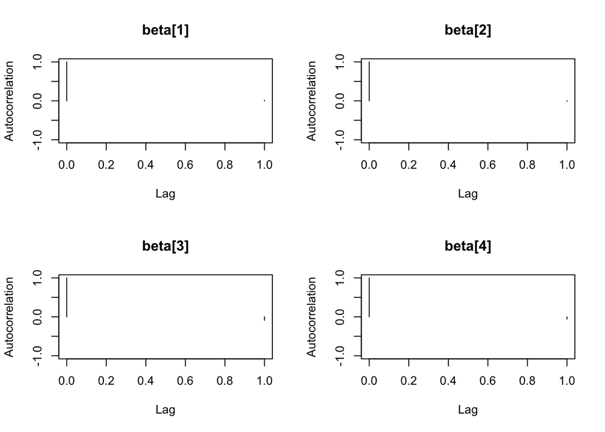

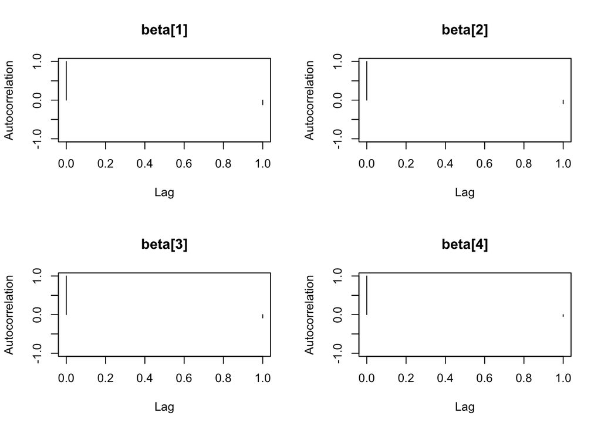

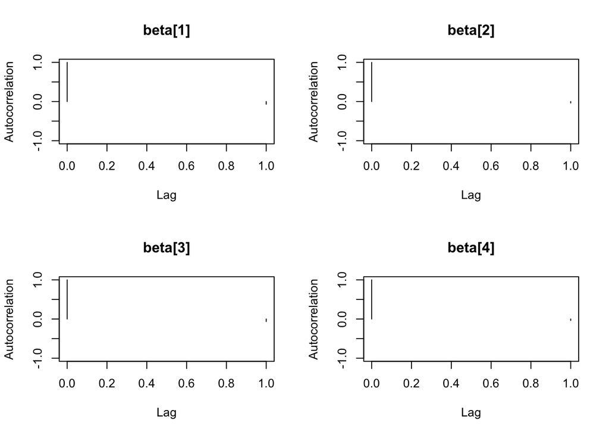

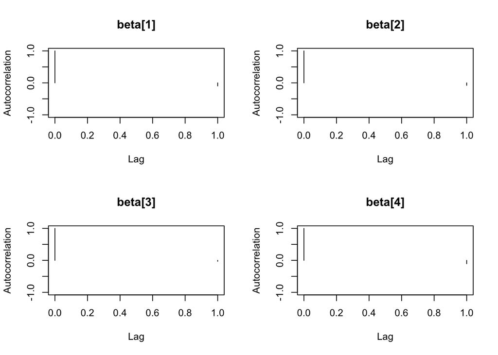

```r
> autocorr.diag(post_beta,1:10)
##              beta[1]      beta[2]      beta[3]       beta[4]
## Lag 1  -6.801117e-02 -0.055625518 -0.067452821 -6.196971e-02
## Lag 2  -2.768209e-02  0.009638867  0.007746856  6.395502e-03
## Lag 3   1.734007e-02  0.002745100 -0.011696885  1.811191e-03
## Lag 4   1.593842e-02 -0.038412342 -0.002561599  2.029865e-02
## Lag 5  -7.904704e-05 -0.011041286 -0.015464863  4.874872e-05
## Lag 6   6.320603e-03 -0.010390968 -0.013328066 -2.603152e-02
## Lag 7   4.603515e-02 -0.007597982 -0.004966721 -1.324718e-02
## Lag 8  -2.819178e-02 -0.004735633  0.007328656 -9.551880e-03
## Lag 9   3.585170e-02  0.018027009  0.018729858  1.199910e-02
## Lag 10  6.248033e-03 -0.020088993  0.004291971  2.417592e-03
> autocorr.plot(post_beta,1:10)
```

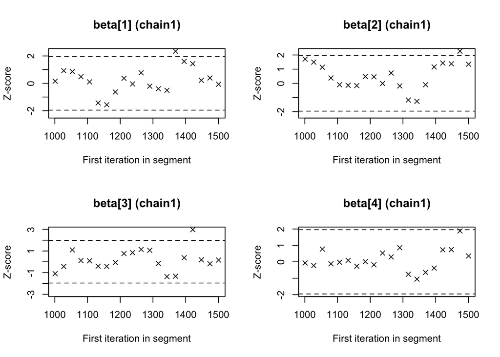

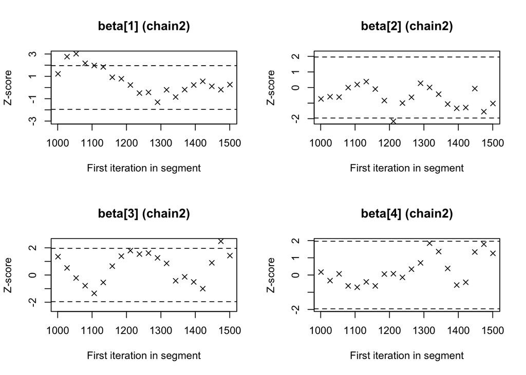

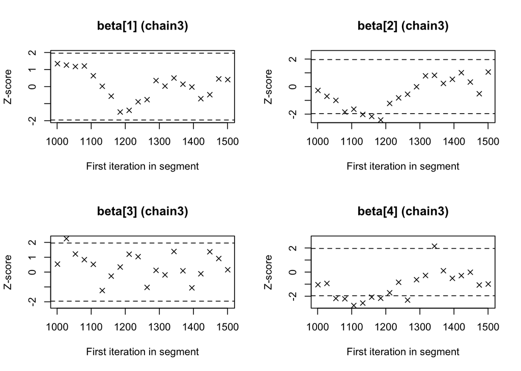

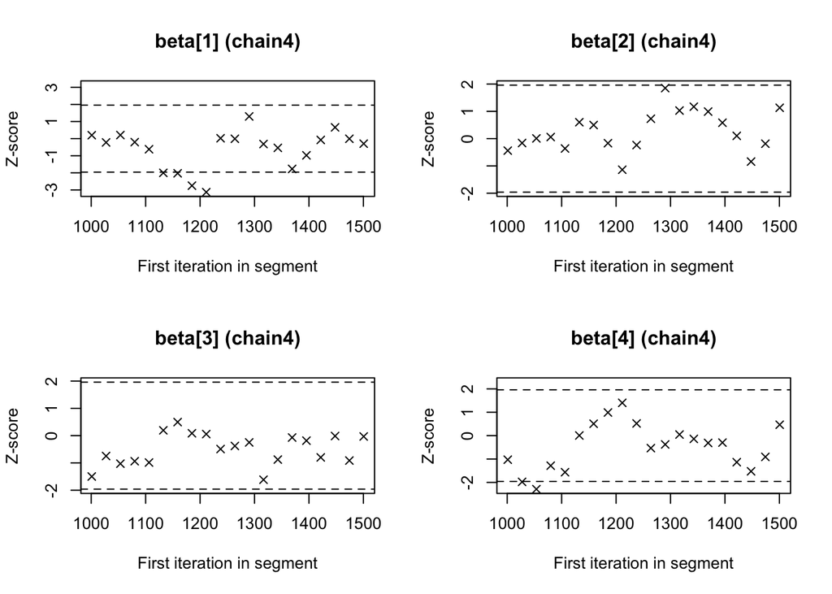

```r
> geweke.diag(post_beta)
## [[1]]
##
## Fraction in 1st window = 0.1
## Fraction in 2nd window = 0.5
##
##  beta[1]  beta[2]  beta[3]  beta[4]
##  0.15413  1.70868 -1.09241 -0.07025
##
##
## [[2]]
##
## Fraction in 1st window = 0.1
## Fraction in 2nd window = 0.5
##
## beta[1] beta[2] beta[3] beta[4]
##  1.2264 -0.7303  1.3501  0.1707
##
##
## [[3]]
##
## Fraction in 1st window = 0.1
## Fraction in 2nd window = 0.5
##
## beta[1] beta[2] beta[3] beta[4]
##  1.3441 -0.2793  0.5393 -1.0443
##
##
## [[4]]
##
## Fraction in 1st window = 0.1
## Fraction in 2nd window = 0.5
##
## beta[1] beta[2] beta[3] beta[4]
##  0.2011 -0.4392 -1.4970 -1.0290
> geweke.plot(post_beta)
```

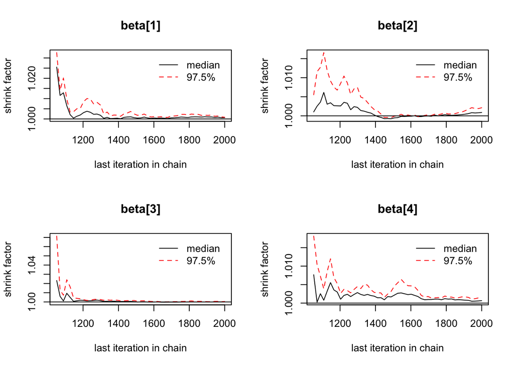

```r
> gelman.diag(post_beta)
## Potential scale reduction factors:
##
##         Point est. Upper C.I.
## beta[1]          1          1
## beta[2]          1          1
## beta[3]          1          1
## beta[4]          1          1
##
## Multivariate psrf
##
## 1
> gelman.plot(post_beta)
```

We will plot the pairwise correlation between the parameters, if each parameters is adding additional independent information, the points should form a shapeless cloud. If you have strong correlation between several parameters, then you may consider dropping some as they do not add extra information.

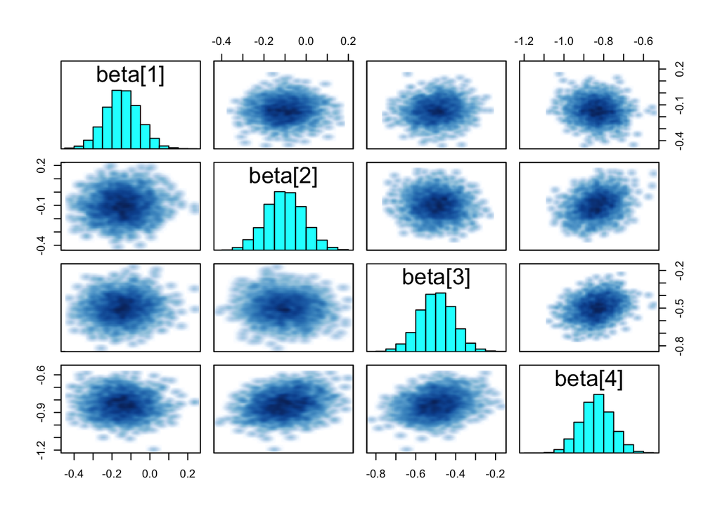

```r
> pairs(m_norm,pars="beta")
```

We can also be interested to plot the *credible intervals*. They are another summary for the different parameters in the models, the red bands in this graph show that the parameters have a probability of 0.8 to be within the bands.

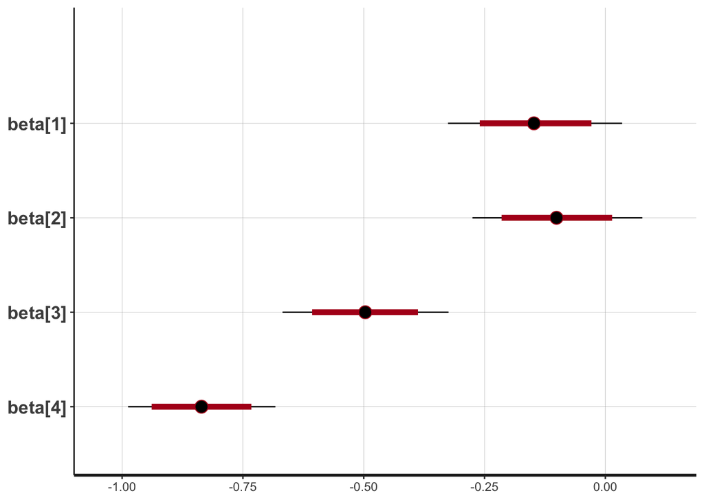

```r
> plot(m_norm,pars=c("beta"))
## ci_level: 0.8 (80% intervals)
## outer_level: 0.95 (95% intervals)
```

We finally plot the regression lines with their credible intervals at different x2 values.

```r
> #getting regression curves plus 95% credible intervals
> new_x<-data.frame(x1=new_X[,2],x2=rep(c("Min","Mean","Max"),each=20))
> new_y<-extract(m_norm,pars="y_pred")
> pred<-apply(new_y[[1]],2,quantile,probs=c(0.025,0.5,0.975)) #the median line with 95% credible intervals
```

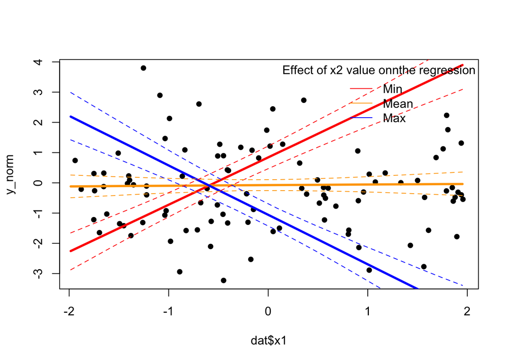

```r
> #plot
> plot(dat$x1,y_norm,pch=16)
> lines(new_x$x1[1:20],pred[2,1:20],col="red",lwd=3)
> lines(new_x$x1[1:20],pred[2,21:40],col="orange",lwd=3)
> lines(new_x$x1[1:20],pred[2,41:60],col="blue",lwd=3)
> lines(new_x$x1[1:20],pred[1,1:20],col="red",lwd=1,lty=2)
> lines(new_x$x1[1:20],pred[1,21:40],col="orange",lwd=1,lty=2)
> lines(new_x$x1[1:20],pred[1,41:60],col="blue",lwd=1,lty=2)
> lines(new_x$x1[1:20],pred[3,1:20],col="red",lwd=1,lty=2)
> lines(new_x$x1[1:20],pred[3,21:40],col="orange",lwd=1,lty=2)
> lines(new_x$x1[1:20],pred[3,41:60],col="blue",lwd=1,lty=2)
> legend("topright",legend=c("Min","Mean","Max"),lty=1,col=c("red","orange","blue"),bty = "n",title = "Effect of x2 value onnthe regression")
```